# Prajapati_M_Final

Prajapati_M & K-State Honor Code: "On my honor, as a student, I have neither given nor received unauthorized aid on this academic work."

```python
import pandas as pd
import numpy as np
import seaborn as sns
import matplotlib.pyplot as plt
%matplotlib inline

#regression packages
import sklearn.linear_model as lm
from sklearn.metrics import mean_squared_error
from sklearn.metrics import explained_variance_score

import statsmodels.api as sm
from statsmodels.formula.api import ols
```

```python
mv = pd.read_csv("data/movie_metadata.csv")
mv.head()
```

|  | color | director_name | num_critic_for_reviews | duration | director_facebook_likes | actor_3_facebook_likes | actor_2_name | actor_1_facebook_likes | gross | genres | ... | num_user_for_reviews | language | country | content_rating | budget | title_year | actor_2_facebook_likes | imdb_score | aspect_ratio | movie_facebook_likes |
| --- | --- | --- | --- | --- | --- | --- | --- | --- | --- | --- | --- | --- | --- | --- | --- | --- | --- | --- | --- | --- | --- |
| 0 | Color | James Cameron | 723.0 | 178.0 | 0.0 | 855.0 | Joel David Moore | 1000.0 | 760505847.0 | Action\|Adventure\|Fantasy\|Sci-Fi | ... | 3054.0 | English | USA | PG-13 | 237000000.0 | 2009.0 | 936.0 | 7.9 | 1.78 | 33000 |
| 1 | Color | Gore Verbinski | 302.0 | 169.0 | 563.0 | 1000.0 | Orlando Bloom | 40000.0 | 309404152.0 | Action\|Adventure\|Fantasy | ... | 1238.0 | English | USA | PG-13 | 300000000.0 | 2007.0 | 5000.0 | 7.1 | 2.35 | 0 |
| 2 | Color | Sam Mendes | 602.0 | 148.0 | 0.0 | 161.0 | Rory Kinnear | 11000.0 | 200074175.0 | Action\|Adventure\|Thriller | ... | 994.0 | English | UK | PG-13 | 245000000.0 | 2015.0 | 393.0 | 6.8 | 2.35 | 85000 |
| 3 | Color | Christopher Nolan | 813.0 | 164.0 | 22000.0 | 23000.0 | Christian Bale | 27000.0 | 448130642.0 | Action\|Thriller | ... | 2701.0 | English | USA | PG-13 | 250000000.0 | 2012.0 | 23000.0 | 8.5 | 2.35 | 164000 |
| 4 | NaN | Doug Walker | NaN | NaN | 131.0 | NaN | Rob Walker | 131.0 | NaN | Documentary | ... | NaN | NaN | NaN | NaN | NaN | NaN | 12.0 | 7.1 | NaN | 0 |

5 rows × 28 columns

```python
mv.isnull().dropna()
```

|  | color | director_name | num_critic_for_reviews | duration | director_facebook_likes | actor_3_facebook_likes | actor_2_name | actor_1_facebook_likes | gross | genres | ... | num_user_for_reviews | language | country | content_rating | budget | title_year | actor_2_facebook_likes | imdb_score | aspect_ratio | movie_facebook_likes |
| --- | --- | --- | --- | --- | --- | --- | --- | --- | --- | --- | --- | --- | --- | --- | --- | --- | --- | --- | --- | --- | --- |
| 0 | False | False | False | False | False | False | False | False | False | False | ... | False | False | False | False | False | False | False | False | False | False |
| 1 | False | False | False | False | False | False | False | False | False | False | ... | False | False | False | False | False | False | False | False | False | False |
| 2 | False | False | False | False | False | False | False | False | False | False | ... | False | False | False | False | False | False | False | False | False | False |
| 3 | False | False | False | False | False | False | False | False | False | False | ... | False | False | False | False | False | False | False | False | False | False |
| 4 | True | False | True | True | False | True | False | False | True | False | ... | True | True | True | True | True | True | False | False | True | False |
| 5 | False | False | False | False | False | False | False | False | False | False | ... | False | False | False | False | False | False | False | False | False | False |
| 6 | False | False | False | False | False | False | False | False | False | False | ... | False | False | False | False | False | False | False | False | False | False |
| 7 | False | False | False | False | False | False | False | False | False | False | ... | False | False | False | False | False | False | False | False | False | False |
| 8 | False | False | False | False | False | False | False | False | False | False | ... | False | False | False | False | False | False | False | False | False | False |
| 9 | False | False | False | False | False | False | False | False | False | False | ... | False | False | False | False | False | False | False | False | False | False |
| 10 | False | False | False | False | False | False | False | False | False | False | ... | False | False | False | False | False | False | False | False | False | False |
| 11 | False | False | False | False | False | False | False | False | False | False | ... | False | False | False | False | False | False | False | False | False | False |
| 12 | False | False | False | False | False | False | False | False | False | False | ... | False | False | False | False | False | False | False | False | False | False |
| 13 | False | False | False | False | False | False | False | False | False | False | ... | False | False | False | False | False | False | False | False | False | False |
| 14 | False | False | False | False | False | False | False | False | False | False | ... | False | False | False | False | False | False | False | False | False | False |
| 15 | False | False | False | False | False | False | False | False | False | False | ... | False | False | False | False | False | False | False | False | False | False |
| 16 | False | False | False | False | False | False | False | False | False | False | ... | False | False | False | False | False | False | False | False | False | False |
| 17 | False | False | False | False | False | False | False | False | False | False | ... | False | False | False | False | False | False | False | False | False | False |
| 18 | False | False | False | False | False | False | False | False | False | False | ... | False | False | False | False | False | False | False | False | False | False |
| 19 | False | False | False | False | False | False | False | False | False | False | ... | False | False | False | False | False | False | False | False | False | False |
| 20 | False | False | False | False | False | False | False | False | False | False | ... | False | False | False | False | False | False | False | False | False | False |
| 21 | False | False | False | False | False | False | False | False | False | False | ... | False | False | False | False | False | False | False | False | False | False |
| 22 | False | False | False | False | False | False | False | False | False | False | ... | False | False | False | False | False | False | False | False | False | False |
| 23 | False | False | False | False | False | False | False | False | False | False | ... | False | False | False | False | False | False | False | False | False | False |
| 24 | False | False | False | False | False | False | False | False | False | False | ... | False | False | False | False | False | False | False | False | False | False |
| 25 | False | False | False | False | False | False | False | False | False | False | ... | False | False | False | False | False | False | False | False | False | False |
| 26 | False | False | False | False | False | False | False | False | False | False | ... | False | False | False | False | False | False | False | False | False | False |
| 27 | False | False | False | False | False | False | False | False | False | False | ... | False | False | False | False | False | False | False | False | False | False |
| 28 | False | False | False | False | False | False | False | False | False | False | ... | False | False | False | False | False | False | False | False | False | False |
| 29 | False | False | False | False | False | False | False | False | False | False | ... | False | False | False | False | False | False | False | False | False | False |
| ... | ... | ... | ... | ... | ... | ... | ... | ... | ... | ... | ... | ... | ... | ... | ... | ... | ... | ... | ... | ... | ... |
| 5013 | False | False | False | False | False | False | False | False | True | False | ... | False | False | False | True | False | False | False | False | False | False |
| 5014 | False | False | False | False | False | False | False | False | True | False | ... | False | False | False | False | True | False | False | False | False | False |
| 5015 | False | False | False | False | False | False | False | False | False | False | ... | False | False | False | False | False | False | False | False | False | False |
| 5016 | False | False | True | False | False | False | False | False | True | False | ... | False | False | False | True | False | False | False | False | True | False |
| 5017 | False | False | False | False | False | False | False | False | True | False | ... | False | False | False | True | False | False | False | False | False | False |
| 5018 | False | False | False | False | False | False | False | False | True | False | ... | False | False | False | True | False | False | False | False | False | False |
| 5019 | False | False | False | False | False | False | False | False | True | False | ... | False | False | False | False | True | False | False | False | False | False |
| 5020 | True | False | True | False | False | False | False | False | True | False | ... | False | False | False | True | False | False | False | False | True | False |
| 5021 | False | False | False | False | False | False | False | False | False | False | ... | False | False | False | False | False | False | False | False | True | False |
| 5022 | False | False | False | False | False | False | False | False | True | False | ... | False | False | False | True | False | False | False | False | True | False |
| 5023 | False | False | False | False | False | False | False | False | False | False | ... | False | False | False | True | False | False | False | False | False | False |
| 5024 | False | False | False | False | False | False | False | False | True | False | ... | False | False | False | False | False | False | False | False | False | False |
| 5025 | False | False | False | False | False | False | False | False | False | False | ... | False | False | False | False | False | False | False | False | False | False |
| 5026 | False | False | False | False | False | False | False | False | False | False | ... | False | False | False | False | False | False | False | False | False | False |
| 5027 | False | False | False | False | False | False | False | False | False | False | ... | False | False | False | False | False | False | False | False | False | False |
| 5028 | False | False | False | False | False | False | False | False | True | False | ... | False | False | False | True | False | False | False | False | False | False |
| 5029 | False | False | False | False | False | False | False | False | False | False | ... | False | False | False | True | False | False | False | False | False | False |
| 5030 | False | False | True | False | False | False | False | False | True | False | ... | False | False | False | True | True | False | False | False | True | False |
| 5031 | False | False | False | False | False | False | False | False | True | False | ... | False | False | False | True | False | False | False | False | False | False |
| 5032 | False | False | False | False | False | False | False | False | True | False | ... | False | False | False | True | True | False | False | False | True | False |
| 5033 | False | False | False | False | False | False | False | False | False | False | ... | False | False | False | False | False | False | False | False | False | False |
| 5034 | False | False | False | False | False | False | False | False | False | False | ... | False | False | False | False | False | False | False | False | True | False |
| 5035 | False | False | False | False | False | False | False | False | False | False | ... | False | False | False | False | False | False | False | False | False | False |
| 5036 | False | False | True | False | False | False | False | False | True | False | ... | False | False | False | False | False | False | False | False | True | False |
| 5037 | False | False | False | False | False | False | False | False | False | False | ... | False | False | False | False | False | False | False | False | True | False |
| 5038 | False | False | False | False | False | False | False | False | True | False | ... | False | False | False | True | True | False | False | False | True | False |
| 5039 | False | True | False | False | True | False | False | False | True | False | ... | False | False | False | False | True | True | False | False | False | False |
| 5040 | False | False | False | False | False | False | False | False | True | False | ... | False | False | False | True | False | False | False | False | True | False |
| 5041 | False | False | False | False | False | False | False | False | False | False | ... | False | False | False | False | True | False | False | False | False | False |
| 5042 | False | False | False | False | False | False | False | False | False | False | ... | False | False | False | False | False | False | False | False | False | False |

5043 rows × 28 columns

```python
mv = mv.fillna('0')
mv
```

|  | color | director_name | num_critic_for_reviews | duration | director_facebook_likes | actor_3_facebook_likes | actor_2_name | actor_1_facebook_likes | gross | genres | ... | num_user_for_reviews | language | country | content_rating | budget | title_year | actor_2_facebook_likes | imdb_score | aspect_ratio | movie_facebook_likes |
| --- | --- | --- | --- | --- | --- | --- | --- | --- | --- | --- | --- | --- | --- | --- | --- | --- | --- | --- | --- | --- | --- |
| 0 | Color | James Cameron | 723 | 178 | 0 | 855 | Joel David Moore | 1000 | 7.60506e+08 | Action\|Adventure\|Fantasy\|Sci-Fi | ... | 3054 | English | USA | PG-13 | 2.37e+08 | 2009 | 936 | 7.9 | 1.78 | 33000 |
| 1 | Color | Gore Verbinski | 302 | 169 | 563 | 1000 | Orlando Bloom | 40000 | 3.09404e+08 | Action\|Adventure\|Fantasy | ... | 1238 | English | USA | PG-13 | 3e+08 | 2007 | 5000 | 7.1 | 2.35 | 0 |
| 2 | Color | Sam Mendes | 602 | 148 | 0 | 161 | Rory Kinnear | 11000 | 2.00074e+08 | Action\|Adventure\|Thriller | ... | 994 | English | UK | PG-13 | 2.45e+08 | 2015 | 393 | 6.8 | 2.35 | 85000 |
| 3 | Color | Christopher Nolan | 813 | 164 | 22000 | 23000 | Christian Bale | 27000 | 4.48131e+08 | Action\|Thriller | ... | 2701 | English | USA | PG-13 | 2.5e+08 | 2012 | 23000 | 8.5 | 2.35 | 164000 |
| 4 | 0 | Doug Walker | 0 | 0 | 131 | 0 | Rob Walker | 131 | 0 | Documentary | ... | 0 | 0 | 0 | 0 | 0 | 0 | 12 | 7.1 | 0 | 0 |
| 5 | Color | Andrew Stanton | 462 | 132 | 475 | 530 | Samantha Morton | 640 | 7.30587e+07 | Action\|Adventure\|Sci-Fi | ... | 738 | English | USA | PG-13 | 2.637e+08 | 2012 | 632 | 6.6 | 2.35 | 24000 |
| 6 | Color | Sam Raimi | 392 | 156 | 0 | 4000 | James Franco | 24000 | 3.3653e+08 | Action\|Adventure\|Romance | ... | 1902 | English | USA | PG-13 | 2.58e+08 | 2007 | 11000 | 6.2 | 2.35 | 0 |
| 7 | Color | Nathan Greno | 324 | 100 | 15 | 284 | Donna Murphy | 799 | 2.00807e+08 | Adventure\|Animation\|Comedy\|Family\|Fantasy\|Musi... | ... | 387 | English | USA | PG | 2.6e+08 | 2010 | 553 | 7.8 | 1.85 | 29000 |
| 8 | Color | Joss Whedon | 635 | 141 | 0 | 19000 | Robert Downey Jr. | 26000 | 4.58992e+08 | Action\|Adventure\|Sci-Fi | ... | 1117 | English | USA | PG-13 | 2.5e+08 | 2015 | 21000 | 7.5 | 2.35 | 118000 |
| 9 | Color | David Yates | 375 | 153 | 282 | 10000 | Daniel Radcliffe | 25000 | 3.01957e+08 | Adventure\|Family\|Fantasy\|Mystery | ... | 973 | English | UK | PG | 2.5e+08 | 2009 | 11000 | 7.5 | 2.35 | 10000 |
| 10 | Color | Zack Snyder | 673 | 183 | 0 | 2000 | Lauren Cohan | 15000 | 3.30249e+08 | Action\|Adventure\|Sci-Fi | ... | 3018 | English | USA | PG-13 | 2.5e+08 | 2016 | 4000 | 6.9 | 2.35 | 197000 |
| 11 | Color | Bryan Singer | 434 | 169 | 0 | 903 | Marlon Brando | 18000 | 2.00069e+08 | Action\|Adventure\|Sci-Fi | ... | 2367 | English | USA | PG-13 | 2.09e+08 | 2006 | 10000 | 6.1 | 2.35 | 0 |
| 12 | Color | Marc Forster | 403 | 106 | 395 | 393 | Mathieu Amalric | 451 | 1.68368e+08 | Action\|Adventure | ... | 1243 | English | UK | PG-13 | 2e+08 | 2008 | 412 | 6.7 | 2.35 | 0 |
| 13 | Color | Gore Verbinski | 313 | 151 | 563 | 1000 | Orlando Bloom | 40000 | 4.23033e+08 | Action\|Adventure\|Fantasy | ... | 1832 | English | USA | PG-13 | 2.25e+08 | 2006 | 5000 | 7.3 | 2.35 | 5000 |
| 14 | Color | Gore Verbinski | 450 | 150 | 563 | 1000 | Ruth Wilson | 40000 | 8.92899e+07 | Action\|Adventure\|Western | ... | 711 | English | USA | PG-13 | 2.15e+08 | 2013 | 2000 | 6.5 | 2.35 | 48000 |
| 15 | Color | Zack Snyder | 733 | 143 | 0 | 748 | Christopher Meloni | 15000 | 2.91022e+08 | Action\|Adventure\|Fantasy\|Sci-Fi | ... | 2536 | English | USA | PG-13 | 2.25e+08 | 2013 | 3000 | 7.2 | 2.35 | 118000 |
| 16 | Color | Andrew Adamson | 258 | 150 | 80 | 201 | Pierfrancesco Favino | 22000 | 1.41614e+08 | Action\|Adventure\|Family\|Fantasy | ... | 438 | English | USA | PG | 2.25e+08 | 2008 | 216 | 6.6 | 2.35 | 0 |
| 17 | Color | Joss Whedon | 703 | 173 | 0 | 19000 | Robert Downey Jr. | 26000 | 6.2328e+08 | Action\|Adventure\|Sci-Fi | ... | 1722 | English | USA | PG-13 | 2.2e+08 | 2012 | 21000 | 8.1 | 1.85 | 123000 |
| 18 | Color | Rob Marshall | 448 | 136 | 252 | 1000 | Sam Claflin | 40000 | 2.41064e+08 | Action\|Adventure\|Fantasy | ... | 484 | English | USA | PG-13 | 2.5e+08 | 2011 | 11000 | 6.7 | 2.35 | 58000 |
| 19 | Color | Barry Sonnenfeld | 451 | 106 | 188 | 718 | Michael Stuhlbarg | 10000 | 1.79021e+08 | Action\|Adventure\|Comedy\|Family\|Fantasy\|Sci-Fi | ... | 341 | English | USA | PG-13 | 2.25e+08 | 2012 | 816 | 6.8 | 1.85 | 40000 |
| 20 | Color | Peter Jackson | 422 | 164 | 0 | 773 | Adam Brown | 5000 | 2.55108e+08 | Adventure\|Fantasy | ... | 802 | English | New Zealand | PG-13 | 2.5e+08 | 2014 | 972 | 7.5 | 2.35 | 65000 |
| 21 | Color | Marc Webb | 599 | 153 | 464 | 963 | Andrew Garfield | 15000 | 2.62031e+08 | Action\|Adventure\|Fantasy | ... | 1225 | English | USA | PG-13 | 2.3e+08 | 2012 | 10000 | 7.0 | 2.35 | 56000 |
| 22 | Color | Ridley Scott | 343 | 156 | 0 | 738 | William Hurt | 891 | 1.0522e+08 | Action\|Adventure\|Drama\|History | ... | 546 | English | USA | PG-13 | 2e+08 | 2010 | 882 | 6.7 | 2.35 | 17000 |
| 23 | Color | Peter Jackson | 509 | 186 | 0 | 773 | Adam Brown | 5000 | 2.58355e+08 | Adventure\|Fantasy | ... | 951 | English | USA | PG-13 | 2.25e+08 | 2013 | 972 | 7.9 | 2.35 | 83000 |
| 24 | Color | Chris Weitz | 251 | 113 | 129 | 1000 | Eva Green | 16000 | 7.00835e+07 | Adventure\|Family\|Fantasy | ... | 666 | English | USA | PG-13 | 1.8e+08 | 2007 | 6000 | 6.1 | 2.35 | 0 |
| 25 | Color | Peter Jackson | 446 | 201 | 0 | 84 | Thomas Kretschmann | 6000 | 2.18051e+08 | Action\|Adventure\|Drama\|Romance | ... | 2618 | English | New Zealand | PG-13 | 2.07e+08 | 2005 | 919 | 7.2 | 2.35 | 0 |
| 26 | Color | James Cameron | 315 | 194 | 0 | 794 | Kate Winslet | 29000 | 6.58672e+08 | Drama\|Romance | ... | 2528 | English | USA | PG-13 | 2e+08 | 1997 | 14000 | 7.7 | 2.35 | 26000 |
| 27 | Color | Anthony Russo | 516 | 147 | 94 | 11000 | Scarlett Johansson | 21000 | 4.07197e+08 | Action\|Adventure\|Sci-Fi | ... | 1022 | English | USA | PG-13 | 2.5e+08 | 2016 | 19000 | 8.2 | 2.35 | 72000 |
| 28 | Color | Peter Berg | 377 | 131 | 532 | 627 | Alexander Skarsgård | 14000 | 6.51732e+07 | Action\|Adventure\|Sci-Fi\|Thriller | ... | 751 | English | USA | PG-13 | 2.09e+08 | 2012 | 10000 | 5.9 | 2.35 | 44000 |
| 29 | Color | Colin Trevorrow | 644 | 124 | 365 | 1000 | Judy Greer | 3000 | 6.52177e+08 | Action\|Adventure\|Sci-Fi\|Thriller | ... | 1290 | English | USA | PG-13 | 1.5e+08 | 2015 | 2000 | 7.0 | 2 | 150000 |
| ... | ... | ... | ... | ... | ... | ... | ... | ... | ... | ... | ... | ... | ... | ... | ... | ... | ... | ... | ... | ... | ... |
| 5013 | Color | Eric Eason | 28 | 79 | 3 | 42 | Panchito Gómez | 93 | 0 | Drama\|Family | ... | 21 | English | USA | 0 | 24000 | 2002 | 46 | 7.0 | 1.78 | 61 |
| 5014 | Color | Uwe Boll | 58 | 80 | 892 | 492 | Katharine Isabelle | 986 | 0 | Action\|Crime\|Thriller | ... | 129 | English | Canada | R | 0 | 2009 | 918 | 6.3 | 2.35 | 0 |
| 5015 | Black and White | Richard Linklater | 61 | 100 | 0 | 0 | Richard Linklater | 5 | 1.22751e+06 | Comedy\|Drama | ... | 80 | English | USA | R | 23000 | 1991 | 0 | 7.1 | 1.37 | 2000 |
| 5016 | Color | Joseph Mazzella | 0 | 90 | 0 | 9 | Mikaal Bates | 313 | 0 | Crime\|Drama\|Thriller | ... | 2 | English | USA | 0 | 25000 | 2015 | 25 | 4.8 | 0 | 33 |
| 5017 | Color | Travis Legge | 1 | 90 | 138 | 138 | Suzi Lorraine | 370 | 0 | Comedy\|Romance | ... | 3 | English | USA | 0 | 22000 | 2013 | 184 | 3.3 | 1.78 | 200 |
| 5018 | Color | Alex Kendrick | 5 | 120 | 589 | 4 | Lisa Arnold | 51 | 0 | Drama | ... | 49 | English | USA | 0 | 20000 | 2003 | 49 | 6.9 | 1.85 | 725 |
| 5019 | Color | Marcus Nispel | 43 | 91 | 158 | 265 | Brittany Curran | 630 | 0 | Horror\|Mystery\|Thriller | ... | 33 | English | USA | R | 0 | 2015 | 512 | 4.6 | 1.85 | 0 |
| 5020 | 0 | Brandon Landers | 0 | 143 | 8 | 8 | Alana Kaniewski | 720 | 0 | Drama\|Horror\|Thriller | ... | 8 | English | USA | 0 | 17350 | 2011 | 19 | 3.0 | 0 | 33 |
| 5021 | Color | Jay Duplass | 51 | 85 | 157 | 10 | Katie Aselton | 830 | 192467 | Comedy\|Drama\|Romance | ... | 71 | English | USA | R | 15000 | 2005 | 224 | 6.6 | 0 | 297 |
| 5022 | Black and White | Jim Chuchu | 6 | 60 | 0 | 4 | Olwenya Maina | 147 | 0 | Drama | ... | 1 | Swahili | Kenya | 0 | 15000 | 2014 | 19 | 7.4 | 0 | 45 |
| 5023 | Color | Daryl Wein | 22 | 88 | 38 | 211 | Heather Burns | 331 | 76382 | Romance | ... | 8 | English | USA | 0 | 15000 | 2009 | 212 | 6.2 | 2.35 | 324 |
| 5024 | Color | Jason Trost | 42 | 78 | 91 | 86 | Jason Trost | 407 | 0 | Sci-Fi\|Thriller | ... | 35 | English | USA | Unrated | 20000 | 2011 | 91 | 4.0 | 2.35 | 835 |
| 5025 | Color | John Waters | 73 | 108 | 0 | 105 | Mink Stole | 462 | 180483 | Comedy\|Crime\|Horror | ... | 183 | English | USA | NC-17 | 10000 | 1972 | 143 | 6.1 | 1.37 | 0 |
| 5026 | Color | Olivier Assayas | 81 | 110 | 107 | 45 | Béatrice Dalle | 576 | 136007 | Drama\|Music\|Romance | ... | 39 | French | France | R | 4500 | 2004 | 133 | 6.9 | 2.35 | 171 |
| 5027 | Color | Jafar Panahi | 64 | 90 | 397 | 0 | Nargess Mamizadeh | 5 | 673780 | Drama | ... | 26 | Persian | Iran | Not Rated | 10000 | 2000 | 0 | 7.5 | 1.85 | 697 |
| 5028 | Black and White | Ivan Kavanagh | 12 | 83 | 18 | 0 | Michael Parle | 10 | 0 | Horror | ... | 1 | English | Ireland | 0 | 10000 | 2007 | 5 | 6.7 | 1.33 | 105 |
| 5029 | Color | Kiyoshi Kurosawa | 78 | 111 | 62 | 6 | Anna Nakagawa | 89 | 94596 | Crime\|Horror\|Mystery\|Thriller | ... | 50 | Japanese | Japan | 0 | 1e+06 | 1997 | 13 | 7.4 | 1.85 | 817 |
| 5030 | Color | Tadeo Garcia | 0 | 84 | 5 | 12 | Michael Cortez | 21 | 0 | Drama | ... | 3 | English | USA | 0 | 0 | 2004 | 20 | 6.1 | 0 | 22 |
| 5031 | Color | Thomas L. Phillips | 13 | 82 | 120 | 84 | Joe Coffey | 785 | 0 | Comedy\|Horror\|Thriller | ... | 8 | English | USA | 0 | 200000 | 2012 | 98 | 5.4 | 16 | 424 |
| 5032 | Color | Ash Baron-Cohen | 10 | 98 | 3 | 152 | Stanley B. Herman | 789 | 0 | Crime\|Drama | ... | 14 | English | USA | 0 | 0 | 1995 | 194 | 6.4 | 0 | 20 |
| 5033 | Color | Shane Carruth | 143 | 77 | 291 | 8 | David Sullivan | 291 | 424760 | Drama\|Sci-Fi\|Thriller | ... | 371 | English | USA | PG-13 | 7000 | 2004 | 45 | 7.0 | 1.85 | 19000 |
| 5034 | Color | Neill Dela Llana | 35 | 80 | 0 | 0 | Edgar Tancangco | 0 | 70071 | Thriller | ... | 35 | English | Philippines | Not Rated | 7000 | 2005 | 0 | 6.3 | 0 | 74 |
| 5035 | Color | Robert Rodriguez | 56 | 81 | 0 | 6 | Peter Marquardt | 121 | 2.04092e+06 | Action\|Crime\|Drama\|Romance\|Thriller | ... | 130 | Spanish | USA | R | 7000 | 1992 | 20 | 6.9 | 1.37 | 0 |
| 5036 | Color | Anthony Vallone | 0 | 84 | 2 | 2 | John Considine | 45 | 0 | Crime\|Drama | ... | 1 | English | USA | PG-13 | 3250 | 2005 | 44 | 7.8 | 0 | 4 |
| 5037 | Color | Edward Burns | 14 | 95 | 0 | 133 | Caitlin FitzGerald | 296 | 4584 | Comedy\|Drama | ... | 14 | English | USA | Not Rated | 9000 | 2011 | 205 | 6.4 | 0 | 413 |
| 5038 | Color | Scott Smith | 1 | 87 | 2 | 318 | Daphne Zuniga | 637 | 0 | Comedy\|Drama | ... | 6 | English | Canada | 0 | 0 | 2013 | 470 | 7.7 | 0 | 84 |
| 5039 | Color | 0 | 43 | 43 | 0 | 319 | Valorie Curry | 841 | 0 | Crime\|Drama\|Mystery\|Thriller | ... | 359 | English | USA | TV-14 | 0 | 0 | 593 | 7.5 | 16 | 32000 |
| 5040 | Color | Benjamin Roberds | 13 | 76 | 0 | 0 | Maxwell Moody | 0 | 0 | Drama\|Horror\|Thriller | ... | 3 | English | USA | 0 | 1400 | 2013 | 0 | 6.3 | 0 | 16 |
| 5041 | Color | Daniel Hsia | 14 | 100 | 0 | 489 | Daniel Henney | 946 | 10443 | Comedy\|Drama\|Romance | ... | 9 | English | USA | PG-13 | 0 | 2012 | 719 | 6.3 | 2.35 | 660 |
| 5042 | Color | Jon Gunn | 43 | 90 | 16 | 16 | Brian Herzlinger | 86 | 85222 | Documentary | ... | 84 | English | USA | PG | 1100 | 2004 | 23 | 6.6 | 1.85 | 456 |

5043 rows × 28 columns

```python
#Exploratory Data Analysis
# correlation analysis
mv.corr()
```

|  | num_voted_users | cast_total_facebook_likes | imdb_score | movie_facebook_likes |
| --- | --- | --- | --- | --- |
| num_voted_users | 1.000000 | 0.265911 | 0.410965 | 0.537924 |
| cast_total_facebook_likes | 0.265911 | 1.000000 | 0.085787 | 0.209786 |
| imdb_score | 0.410965 | 0.085787 | 1.000000 | 0.247049 |
| movie_facebook_likes | 0.537924 | 0.209786 | 0.247049 | 1.000000 |

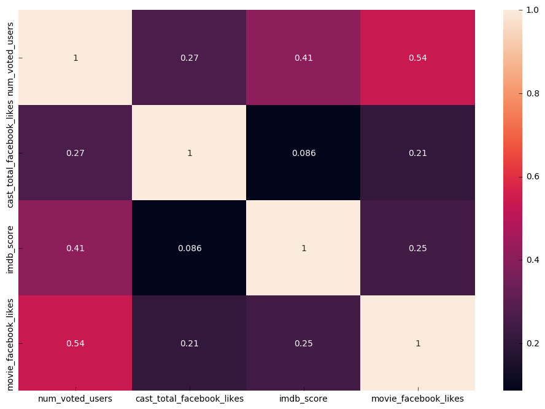

```python
# correlation heatmap
plt.figure(figsize=(12,8))
sns.heatmap(mv.corr(), annot=True)
```

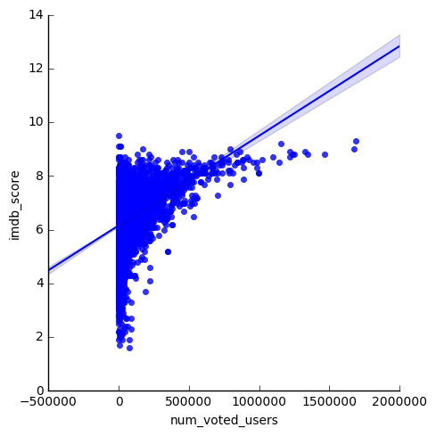

```python
sns.lmplot('num_voted_users', 'imdb_score', mv)
```

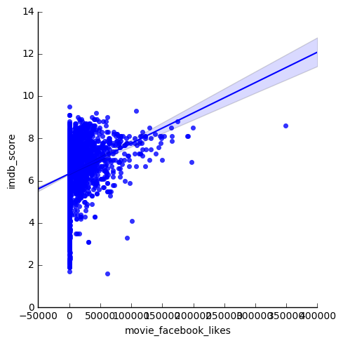

```python
sns.lmplot('movie_facebook_likes', 'imdb_score', mv)
```

Model Development: Regression

```python
#assigning columns to X and Y variables
X = mv['movie_facebook_likes']
y = mv['imdb_score']
```

```python
# creating the modelfor linearRegression called Lr.
model1 = lm.LinearRegression()
# training the model on our training dataset.
model1.fit(X[:,np.newaxis], y)    ## X needs to be 2d for LinearRegression so add [:,np.newaxis]
# predict points with trained model.
model1_y = model1.predict(X[:,np.newaxis])
```

```python
# The coefficients
print 'Coefficients: ', model1.coef_
# y-intercept
print "y-intercept ", model1.intercept_
```

```
Coefficients:  [1.43867394e-05]
y-intercept  6.3338635266320455
```

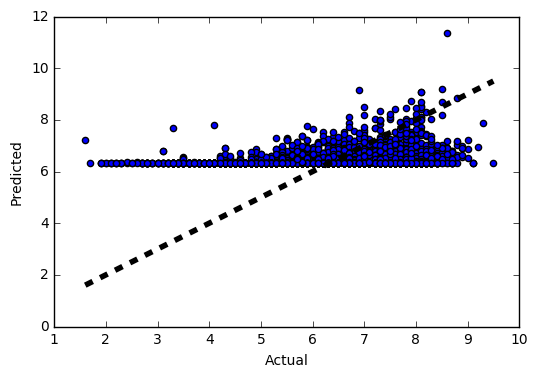

```python
#evaluating performance of our model's prediction using visualization

plt.subplots()
plt.scatter(y, model1_y)
plt.plot([y.min(), y.max()], [y.min(), y.max()], 'k--', lw=4)   #dotted line represents perfect prediction (actual = predicted)
plt.xlabel('Actual')
plt.ylabel('Predicted')
plt.show()
```

```python
#2nd model with num voted users
X = mv['num_voted_users']
y = mv['imdb_score']
model2 = lm.LinearRegression()
model2.fit(X[:,np.newaxis], y)
model2_y = model2.predict(X[:,np.newaxis])
print 'Coefficients: ', model2.coef_
print "y-intercept ", model2.intercept_
```

```
Coefficients:  [3.33886421e-06]
y-intercept  6.162780989116084
```

```python
#3rd model with cast_total_facebook_likes linear regression model (model3).
X = mv['cast_total_facebook_likes']
y = mv['imdb_score']
model3 = lm.LinearRegression()
model3.fit(X[:,np.newaxis], y)
model3_y = model2.predict(X[:,np.newaxis])
print 'Coefficients: ', model3.coef_
print "y-intercept ", model2.intercept_
```

```
Coefficients:  [5.31390516e-06]
y-intercept  6.162780989116084
```

```python
print "%.10f" % model3.coef_
```

```
0.0000053139
```

```python
# evaluate model (1st)
print "mean square error: ", mean_squared_error(y, model1_y)
print explained_variance_score(y, model1_y)
```

```
mean square error:  1.1883892477406823
0.061032970753557514
```

```python
# evaluate model (2nd)
print "mean square error: ", mean_squared_error(y, model2_y)
print explained_variance_score(y, model2_y)
```

```
mean square error:  1.051878617399314
0.16889239583324656
```

```python
# evaluate model (3rd)
print "mean square error: ", mean_squared_error(y, model3_y)
print explained_variance_score(y, model3_y)
```

```
mean square error:  1.3186025493029536
0.006342819873555894
```

Regression using Statsmodels

```python
runs_reg_model1 = ols("imdb_score~movie_facebook_likes",mv)
runs_reg1 = runs_reg_model1.fit()
print runs_reg1.summary()
```

```
                            OLS Regression Results
==============================================================================
Dep. Variable:             imdb_score   R-squared:                       0.061
Model:                            OLS   Adj. R-squared:                  0.061
Method:                 Least Squares   F-statistic:                     327.7
Date:                Tue, 04 Dec 2018   Prob (F-statistic):           5.27e-71
Time:                        17:23:38   Log-Likelihood:                -7590.9
No. Observations:                5043   AIC:                         1.519e+04
Df Residuals:                    5041   BIC:                         1.520e+04
Df Model:                           1
Covariance Type:            nonrobust
========================================================================================
                           coef    std err          t      P>|t|      [0.025      0.975]
----------------------------------------------------------------------------------------
Intercept                6.3339      0.016    384.384      0.000       6.302       6.366
movie_facebook_likes  1.439e-05   7.95e-07     18.102      0.000    1.28e-05    1.59e-05
==============================================================================
Omnibus:                      520.916   Durbin-Watson:                   1.890
Prob(Omnibus):                  0.000   Jarque-Bera (JB):              763.568
Skew:                          -0.786   Prob(JB):                    1.56e-166
Kurtosis:                       4.077   Cond. No.                     2.23e+04
==============================================================================

Warnings:
[1] Standard Errors assume that the covariance matrix of the errors is correctly specified.
[2] The condition number is large, 2.23e+04. This might indicate that there are
strong multicollinearity or other numerical problems.
```

```python
runs_reg_model2 = ols("imdb_score~num_voted_users",mv)
runs_reg2 = runs_reg_model2.fit()
print runs_reg2.summary()
```

```
                            OLS Regression Results
==============================================================================
Dep. Variable:             imdb_score   R-squared:                       0.169
Model:                            OLS   Adj. R-squared:                  0.169
Method:                 Least Squares   F-statistic:                     1024.
Date:                Tue, 04 Dec 2018   Prob (F-statistic):          8.56e-205
Time:                        17:23:39   Log-Likelihood:                -7283.2
No. Observations:                5043   AIC:                         1.457e+04
Df Residuals:                    5041   BIC:                         1.458e+04
Df Model:                           1
Covariance Type:            nonrobust
===================================================================================
                      coef    std err          t      P>|t|      [0.025      0.975]
-----------------------------------------------------------------------------------
Intercept           6.1628      0.017    365.150      0.000       6.130       6.196
num_voted_users  3.339e-06   1.04e-07     32.006      0.000    3.13e-06    3.54e-06
==============================================================================
Omnibus:                      544.905   Durbin-Watson:                   1.888
Prob(Omnibus):                  0.000   Jarque-Bera (JB):              851.883
Skew:                          -0.784   Prob(JB):                    1.04e-185
Kurtosis:                       4.263   Cond. No.                     1.89e+05
==============================================================================

Warnings:
[1] Standard Errors assume that the covariance matrix of the errors is correctly specified.
[2] The condition number is large, 1.89e+05. This might indicate that there are
strong multicollinearity or other numerical problems.
```

```python
runs_reg2.mse_resid
```

```
1.0522959467456336
```

The first model has a R-squared of 0.061.

The second model has a R-squared of 0.169.

Based on this analysis, we could confirm that the second model model using num_voted_users is a better model.

```python
# Develop the 3rd model

runs_reg_model3 = ols("imdb_score~cast_total_facebook_likes",mv)
runs_reg3 = runs_reg_model3.fit()
print runs_reg3.summary()
```

```
                            OLS Regression Results
==============================================================================
Dep. Variable:             imdb_score   R-squared:                       0.007
Model:                            OLS   Adj. R-squared:                  0.007
Method:                 Least Squares   F-statistic:                     37.37
Date:                Tue, 04 Dec 2018   Prob (F-statistic):           1.05e-09
Time:                        17:23:39   Log-Likelihood:                -7731.1
No. Observations:                5043   AIC:                         1.547e+04
Df Residuals:                    5041   BIC:                         1.548e+04
Df Model:                           1
Covariance Type:            nonrobust
=============================================================================================
                                coef    std err          t      P>|t|      [0.025      0.975]
---------------------------------------------------------------------------------------------
Intercept                     6.3906      0.018    357.081      0.000       6.356       6.426
cast_total_facebook_likes  5.314e-06   8.69e-07      6.113      0.000    3.61e-06    7.02e-06
==============================================================================
Omnibus:                      449.174   Durbin-Watson:                   1.902
Prob(Omnibus):                  0.000   Jarque-Bera (JB):              617.922
Skew:                          -0.730   Prob(JB):                    6.61e-135
Kurtosis:                       3.901   Cond. No.                     2.33e+04
==============================================================================

Warnings:
[1] Standard Errors assume that the covariance matrix of the errors is correctly specified.
[2] The condition number is large, 2.33e+04. This might indicate that there are
strong multicollinearity or other numerical problems.
```

Plots (Statsmodels)

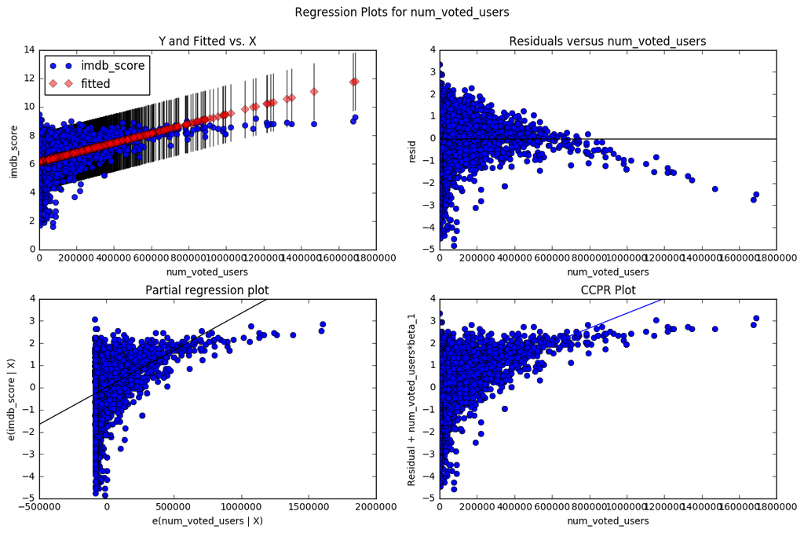

```python
fig = plt.figure(figsize=(12,8))
fig = sm.graphics.plot_regress_exog(runs_reg2, "num_voted_users", fig=fig)
```

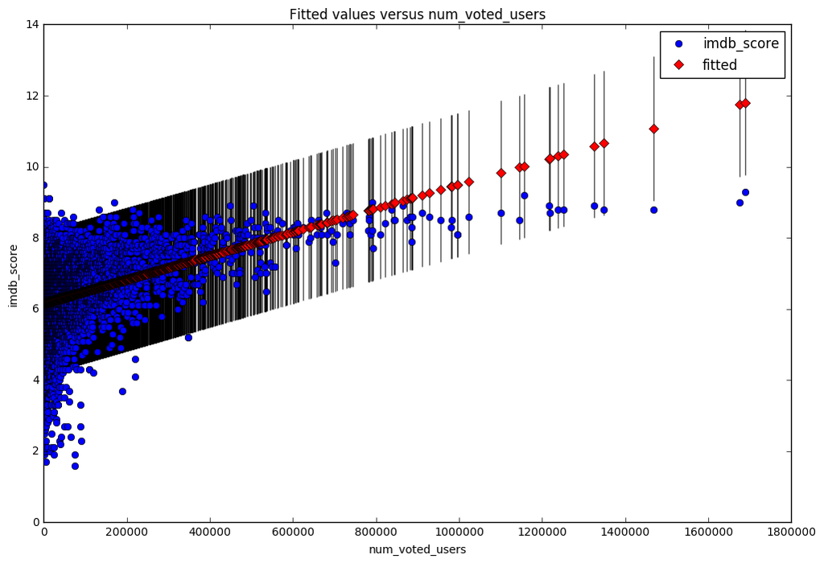

```python
# fit plot

fig, ax = plt.subplots(figsize=(12, 8))
fig = sm.graphics.plot_fit(runs_reg2, "num_voted_users", ax=ax)
```

Multiple Regression Analysis:

```python
mv2 = pd.read_csv("data/movie_metadata.csv")
mv2.head()
```

|  | color | director_name | num_critic_for_reviews | duration | director_facebook_likes | actor_3_facebook_likes | actor_2_name | actor_1_facebook_likes | gross | genres | ... | num_user_for_reviews | language | country | content_rating | budget | title_year | actor_2_facebook_likes | imdb_score | aspect_ratio | movie_facebook_likes |
| --- | --- | --- | --- | --- | --- | --- | --- | --- | --- | --- | --- | --- | --- | --- | --- | --- | --- | --- | --- | --- | --- |
| 0 | Color | James Cameron | 723.0 | 178.0 | 0.0 | 855.0 | Joel David Moore | 1000.0 | 760505847.0 | Action\|Adventure\|Fantasy\|Sci-Fi | ... | 3054.0 | English | USA | PG-13 | 237000000.0 | 2009.0 | 936.0 | 7.9 | 1.78 | 33000 |
| 1 | Color | Gore Verbinski | 302.0 | 169.0 | 563.0 | 1000.0 | Orlando Bloom | 40000.0 | 309404152.0 | Action\|Adventure\|Fantasy | ... | 1238.0 | English | USA | PG-13 | 300000000.0 | 2007.0 | 5000.0 | 7.1 | 2.35 | 0 |
| 2 | Color | Sam Mendes | 602.0 | 148.0 | 0.0 | 161.0 | Rory Kinnear | 11000.0 | 200074175.0 | Action\|Adventure\|Thriller | ... | 994.0 | English | UK | PG-13 | 245000000.0 | 2015.0 | 393.0 | 6.8 | 2.35 | 85000 |
| 3 | Color | Christopher Nolan | 813.0 | 164.0 | 22000.0 | 23000.0 | Christian Bale | 27000.0 | 448130642.0 | Action\|Thriller | ... | 2701.0 | English | USA | PG-13 | 250000000.0 | 2012.0 | 23000.0 | 8.5 | 2.35 | 164000 |
| 4 | NaN | Doug Walker | NaN | NaN | 131.0 | NaN | Rob Walker | 131.0 | NaN | Documentary | ... | NaN | NaN | NaN | NaN | NaN | NaN | 12.0 | 7.1 | NaN | 0 |

5 rows × 28 columns

```python
mv2 = mv2.fillna('0')
mv2
```

|  | color | director_name | num_critic_for_reviews | duration | director_facebook_likes | actor_3_facebook_likes | actor_2_name | actor_1_facebook_likes | gross | genres | ... | num_user_for_reviews | language | country | content_rating | budget | title_year | actor_2_facebook_likes | imdb_score | aspect_ratio | movie_facebook_likes |
| --- | --- | --- | --- | --- | --- | --- | --- | --- | --- | --- | --- | --- | --- | --- | --- | --- | --- | --- | --- | --- | --- |
| 0 | Color | James Cameron | 723 | 178 | 0 | 855 | Joel David Moore | 1000 | 7.60506e+08 | Action\|Adventure\|Fantasy\|Sci-Fi | ... | 3054 | English | USA | PG-13 | 2.37e+08 | 2009 | 936 | 7.9 | 1.78 | 33000 |
| 1 | Color | Gore Verbinski | 302 | 169 | 563 | 1000 | Orlando Bloom | 40000 | 3.09404e+08 | Action\|Adventure\|Fantasy | ... | 1238 | English | USA | PG-13 | 3e+08 | 2007 | 5000 | 7.1 | 2.35 | 0 |
| 2 | Color | Sam Mendes | 602 | 148 | 0 | 161 | Rory Kinnear | 11000 | 2.00074e+08 | Action\|Adventure\|Thriller | ... | 994 | English | UK | PG-13 | 2.45e+08 | 2015 | 393 | 6.8 | 2.35 | 85000 |
| 3 | Color | Christopher Nolan | 813 | 164 | 22000 | 23000 | Christian Bale | 27000 | 4.48131e+08 | Action\|Thriller | ... | 2701 | English | USA | PG-13 | 2.5e+08 | 2012 | 23000 | 8.5 | 2.35 | 164000 |
| 4 | 0 | Doug Walker | 0 | 0 | 131 | 0 | Rob Walker | 131 | 0 | Documentary | ... | 0 | 0 | 0 | 0 | 0 | 0 | 12 | 7.1 | 0 | 0 |
| 5 | Color | Andrew Stanton | 462 | 132 | 475 | 530 | Samantha Morton | 640 | 7.30587e+07 | Action\|Adventure\|Sci-Fi | ... | 738 | English | USA | PG-13 | 2.637e+08 | 2012 | 632 | 6.6 | 2.35 | 24000 |
| 6 | Color | Sam Raimi | 392 | 156 | 0 | 4000 | James Franco | 24000 | 3.3653e+08 | Action\|Adventure\|Romance | ... | 1902 | English | USA | PG-13 | 2.58e+08 | 2007 | 11000 | 6.2 | 2.35 | 0 |
| 7 | Color | Nathan Greno | 324 | 100 | 15 | 284 | Donna Murphy | 799 | 2.00807e+08 | Adventure\|Animation\|Comedy\|Family\|Fantasy\|Musi... | ... | 387 | English | USA | PG | 2.6e+08 | 2010 | 553 | 7.8 | 1.85 | 29000 |
| 8 | Color | Joss Whedon | 635 | 141 | 0 | 19000 | Robert Downey Jr. | 26000 | 4.58992e+08 | Action\|Adventure\|Sci-Fi | ... | 1117 | English | USA | PG-13 | 2.5e+08 | 2015 | 21000 | 7.5 | 2.35 | 118000 |
| 9 | Color | David Yates | 375 | 153 | 282 | 10000 | Daniel Radcliffe | 25000 | 3.01957e+08 | Adventure\|Family\|Fantasy\|Mystery | ... | 973 | English | UK | PG | 2.5e+08 | 2009 | 11000 | 7.5 | 2.35 | 10000 |
| 10 | Color | Zack Snyder | 673 | 183 | 0 | 2000 | Lauren Cohan | 15000 | 3.30249e+08 | Action\|Adventure\|Sci-Fi | ... | 3018 | English | USA | PG-13 | 2.5e+08 | 2016 | 4000 | 6.9 | 2.35 | 197000 |
| 11 | Color | Bryan Singer | 434 | 169 | 0 | 903 | Marlon Brando | 18000 | 2.00069e+08 | Action\|Adventure\|Sci-Fi | ... | 2367 | English | USA | PG-13 | 2.09e+08 | 2006 | 10000 | 6.1 | 2.35 | 0 |
| 12 | Color | Marc Forster | 403 | 106 | 395 | 393 | Mathieu Amalric | 451 | 1.68368e+08 | Action\|Adventure | ... | 1243 | English | UK | PG-13 | 2e+08 | 2008 | 412 | 6.7 | 2.35 | 0 |
| 13 | Color | Gore Verbinski | 313 | 151 | 563 | 1000 | Orlando Bloom | 40000 | 4.23033e+08 | Action\|Adventure\|Fantasy | ... | 1832 | English | USA | PG-13 | 2.25e+08 | 2006 | 5000 | 7.3 | 2.35 | 5000 |
| 14 | Color | Gore Verbinski | 450 | 150 | 563 | 1000 | Ruth Wilson | 40000 | 8.92899e+07 | Action\|Adventure\|Western | ... | 711 | English | USA | PG-13 | 2.15e+08 | 2013 | 2000 | 6.5 | 2.35 | 48000 |
| 15 | Color | Zack Snyder | 733 | 143 | 0 | 748 | Christopher Meloni | 15000 | 2.91022e+08 | Action\|Adventure\|Fantasy\|Sci-Fi | ... | 2536 | English | USA | PG-13 | 2.25e+08 | 2013 | 3000 | 7.2 | 2.35 | 118000 |
| 16 | Color | Andrew Adamson | 258 | 150 | 80 | 201 | Pierfrancesco Favino | 22000 | 1.41614e+08 | Action\|Adventure\|Family\|Fantasy | ... | 438 | English | USA | PG | 2.25e+08 | 2008 | 216 | 6.6 | 2.35 | 0 |
| 17 | Color | Joss Whedon | 703 | 173 | 0 | 19000 | Robert Downey Jr. | 26000 | 6.2328e+08 | Action\|Adventure\|Sci-Fi | ... | 1722 | English | USA | PG-13 | 2.2e+08 | 2012 | 21000 | 8.1 | 1.85 | 123000 |
| 18 | Color | Rob Marshall | 448 | 136 | 252 | 1000 | Sam Claflin | 40000 | 2.41064e+08 | Action\|Adventure\|Fantasy | ... | 484 | English | USA | PG-13 | 2.5e+08 | 2011 | 11000 | 6.7 | 2.35 | 58000 |
| 19 | Color | Barry Sonnenfeld | 451 | 106 | 188 | 718 | Michael Stuhlbarg | 10000 | 1.79021e+08 | Action\|Adventure\|Comedy\|Family\|Fantasy\|Sci-Fi | ... | 341 | English | USA | PG-13 | 2.25e+08 | 2012 | 816 | 6.8 | 1.85 | 40000 |
| 20 | Color | Peter Jackson | 422 | 164 | 0 | 773 | Adam Brown | 5000 | 2.55108e+08 | Adventure\|Fantasy | ... | 802 | English | New Zealand | PG-13 | 2.5e+08 | 2014 | 972 | 7.5 | 2.35 | 65000 |
| 21 | Color | Marc Webb | 599 | 153 | 464 | 963 | Andrew Garfield | 15000 | 2.62031e+08 | Action\|Adventure\|Fantasy | ... | 1225 | English | USA | PG-13 | 2.3e+08 | 2012 | 10000 | 7.0 | 2.35 | 56000 |
| 22 | Color | Ridley Scott | 343 | 156 | 0 | 738 | William Hurt | 891 | 1.0522e+08 | Action\|Adventure\|Drama\|History | ... | 546 | English | USA | PG-13 | 2e+08 | 2010 | 882 | 6.7 | 2.35 | 17000 |
| 23 | Color | Peter Jackson | 509 | 186 | 0 | 773 | Adam Brown | 5000 | 2.58355e+08 | Adventure\|Fantasy | ... | 951 | English | USA | PG-13 | 2.25e+08 | 2013 | 972 | 7.9 | 2.35 | 83000 |
| 24 | Color | Chris Weitz | 251 | 113 | 129 | 1000 | Eva Green | 16000 | 7.00835e+07 | Adventure\|Family\|Fantasy | ... | 666 | English | USA | PG-13 | 1.8e+08 | 2007 | 6000 | 6.1 | 2.35 | 0 |
| 25 | Color | Peter Jackson | 446 | 201 | 0 | 84 | Thomas Kretschmann | 6000 | 2.18051e+08 | Action\|Adventure\|Drama\|Romance | ... | 2618 | English | New Zealand | PG-13 | 2.07e+08 | 2005 | 919 | 7.2 | 2.35 | 0 |
| 26 | Color | James Cameron | 315 | 194 | 0 | 794 | Kate Winslet | 29000 | 6.58672e+08 | Drama\|Romance | ... | 2528 | English | USA | PG-13 | 2e+08 | 1997 | 14000 | 7.7 | 2.35 | 26000 |
| 27 | Color | Anthony Russo | 516 | 147 | 94 | 11000 | Scarlett Johansson | 21000 | 4.07197e+08 | Action\|Adventure\|Sci-Fi | ... | 1022 | English | USA | PG-13 | 2.5e+08 | 2016 | 19000 | 8.2 | 2.35 | 72000 |
| 28 | Color | Peter Berg | 377 | 131 | 532 | 627 | Alexander Skarsgård | 14000 | 6.51732e+07 | Action\|Adventure\|Sci-Fi\|Thriller | ... | 751 | English | USA | PG-13 | 2.09e+08 | 2012 | 10000 | 5.9 | 2.35 | 44000 |
| 29 | Color | Colin Trevorrow | 644 | 124 | 365 | 1000 | Judy Greer | 3000 | 6.52177e+08 | Action\|Adventure\|Sci-Fi\|Thriller | ... | 1290 | English | USA | PG-13 | 1.5e+08 | 2015 | 2000 | 7.0 | 2 | 150000 |
| ... | ... | ... | ... | ... | ... | ... | ... | ... | ... | ... | ... | ... | ... | ... | ... | ... | ... | ... | ... | ... | ... |
| 5013 | Color | Eric Eason | 28 | 79 | 3 | 42 | Panchito Gómez | 93 | 0 | Drama\|Family | ... | 21 | English | USA | 0 | 24000 | 2002 | 46 | 7.0 | 1.78 | 61 |
| 5014 | Color | Uwe Boll | 58 | 80 | 892 | 492 | Katharine Isabelle | 986 | 0 | Action\|Crime\|Thriller | ... | 129 | English | Canada | R | 0 | 2009 | 918 | 6.3 | 2.35 | 0 |
| 5015 | Black and White | Richard Linklater | 61 | 100 | 0 | 0 | Richard Linklater | 5 | 1.22751e+06 | Comedy\|Drama | ... | 80 | English | USA | R | 23000 | 1991 | 0 | 7.1 | 1.37 | 2000 |
| 5016 | Color | Joseph Mazzella | 0 | 90 | 0 | 9 | Mikaal Bates | 313 | 0 | Crime\|Drama\|Thriller | ... | 2 | English | USA | 0 | 25000 | 2015 | 25 | 4.8 | 0 | 33 |
| 5017 | Color | Travis Legge | 1 | 90 | 138 | 138 | Suzi Lorraine | 370 | 0 | Comedy\|Romance | ... | 3 | English | USA | 0 | 22000 | 2013 | 184 | 3.3 | 1.78 | 200 |
| 5018 | Color | Alex Kendrick | 5 | 120 | 589 | 4 | Lisa Arnold | 51 | 0 | Drama | ... | 49 | English | USA | 0 | 20000 | 2003 | 49 | 6.9 | 1.85 | 725 |
| 5019 | Color | Marcus Nispel | 43 | 91 | 158 | 265 | Brittany Curran | 630 | 0 | Horror\|Mystery\|Thriller | ... | 33 | English | USA | R | 0 | 2015 | 512 | 4.6 | 1.85 | 0 |
| 5020 | 0 | Brandon Landers | 0 | 143 | 8 | 8 | Alana Kaniewski | 720 | 0 | Drama\|Horror\|Thriller | ... | 8 | English | USA | 0 | 17350 | 2011 | 19 | 3.0 | 0 | 33 |
| 5021 | Color | Jay Duplass | 51 | 85 | 157 | 10 | Katie Aselton | 830 | 192467 | Comedy\|Drama\|Romance | ... | 71 | English | USA | R | 15000 | 2005 | 224 | 6.6 | 0 | 297 |
| 5022 | Black and White | Jim Chuchu | 6 | 60 | 0 | 4 | Olwenya Maina | 147 | 0 | Drama | ... | 1 | Swahili | Kenya | 0 | 15000 | 2014 | 19 | 7.4 | 0 | 45 |
| 5023 | Color | Daryl Wein | 22 | 88 | 38 | 211 | Heather Burns | 331 | 76382 | Romance | ... | 8 | English | USA | 0 | 15000 | 2009 | 212 | 6.2 | 2.35 | 324 |
| 5024 | Color | Jason Trost | 42 | 78 | 91 | 86 | Jason Trost | 407 | 0 | Sci-Fi\|Thriller | ... | 35 | English | USA | Unrated | 20000 | 2011 | 91 | 4.0 | 2.35 | 835 |
| 5025 | Color | John Waters | 73 | 108 | 0 | 105 | Mink Stole | 462 | 180483 | Comedy\|Crime\|Horror | ... | 183 | English | USA | NC-17 | 10000 | 1972 | 143 | 6.1 | 1.37 | 0 |
| 5026 | Color | Olivier Assayas | 81 | 110 | 107 | 45 | Béatrice Dalle | 576 | 136007 | Drama\|Music\|Romance | ... | 39 | French | France | R | 4500 | 2004 | 133 | 6.9 | 2.35 | 171 |
| 5027 | Color | Jafar Panahi | 64 | 90 | 397 | 0 | Nargess Mamizadeh | 5 | 673780 | Drama | ... | 26 | Persian | Iran | Not Rated | 10000 | 2000 | 0 | 7.5 | 1.85 | 697 |
| 5028 | Black and White | Ivan Kavanagh | 12 | 83 | 18 | 0 | Michael Parle | 10 | 0 | Horror | ... | 1 | English | Ireland | 0 | 10000 | 2007 | 5 | 6.7 | 1.33 | 105 |
| 5029 | Color | Kiyoshi Kurosawa | 78 | 111 | 62 | 6 | Anna Nakagawa | 89 | 94596 | Crime\|Horror\|Mystery\|Thriller | ... | 50 | Japanese | Japan | 0 | 1e+06 | 1997 | 13 | 7.4 | 1.85 | 817 |
| 5030 | Color | Tadeo Garcia | 0 | 84 | 5 | 12 | Michael Cortez | 21 | 0 | Drama | ... | 3 | English | USA | 0 | 0 | 2004 | 20 | 6.1 | 0 | 22 |
| 5031 | Color | Thomas L. Phillips | 13 | 82 | 120 | 84 | Joe Coffey | 785 | 0 | Comedy\|Horror\|Thriller | ... | 8 | English | USA | 0 | 200000 | 2012 | 98 | 5.4 | 16 | 424 |
| 5032 | Color | Ash Baron-Cohen | 10 | 98 | 3 | 152 | Stanley B. Herman | 789 | 0 | Crime\|Drama | ... | 14 | English | USA | 0 | 0 | 1995 | 194 | 6.4 | 0 | 20 |
| 5033 | Color | Shane Carruth | 143 | 77 | 291 | 8 | David Sullivan | 291 | 424760 | Drama\|Sci-Fi\|Thriller | ... | 371 | English | USA | PG-13 | 7000 | 2004 | 45 | 7.0 | 1.85 | 19000 |
| 5034 | Color | Neill Dela Llana | 35 | 80 | 0 | 0 | Edgar Tancangco | 0 | 70071 | Thriller | ... | 35 | English | Philippines | Not Rated | 7000 | 2005 | 0 | 6.3 | 0 | 74 |
| 5035 | Color | Robert Rodriguez | 56 | 81 | 0 | 6 | Peter Marquardt | 121 | 2.04092e+06 | Action\|Crime\|Drama\|Romance\|Thriller | ... | 130 | Spanish | USA | R | 7000 | 1992 | 20 | 6.9 | 1.37 | 0 |
| 5036 | Color | Anthony Vallone | 0 | 84 | 2 | 2 | John Considine | 45 | 0 | Crime\|Drama | ... | 1 | English | USA | PG-13 | 3250 | 2005 | 44 | 7.8 | 0 | 4 |
| 5037 | Color | Edward Burns | 14 | 95 | 0 | 133 | Caitlin FitzGerald | 296 | 4584 | Comedy\|Drama | ... | 14 | English | USA | Not Rated | 9000 | 2011 | 205 | 6.4 | 0 | 413 |
| 5038 | Color | Scott Smith | 1 | 87 | 2 | 318 | Daphne Zuniga | 637 | 0 | Comedy\|Drama | ... | 6 | English | Canada | 0 | 0 | 2013 | 470 | 7.7 | 0 | 84 |
| 5039 | Color | 0 | 43 | 43 | 0 | 319 | Valorie Curry | 841 | 0 | Crime\|Drama\|Mystery\|Thriller | ... | 359 | English | USA | TV-14 | 0 | 0 | 593 | 7.5 | 16 | 32000 |
| 5040 | Color | Benjamin Roberds | 13 | 76 | 0 | 0 | Maxwell Moody | 0 | 0 | Drama\|Horror\|Thriller | ... | 3 | English | USA | 0 | 1400 | 2013 | 0 | 6.3 | 0 | 16 |
| 5041 | Color | Daniel Hsia | 14 | 100 | 0 | 489 | Daniel Henney | 946 | 10443 | Comedy\|Drama\|Romance | ... | 9 | English | USA | PG-13 | 0 | 2012 | 719 | 6.3 | 2.35 | 660 |
| 5042 | Color | Jon Gunn | 43 | 90 | 16 | 16 | Brian Herzlinger | 86 | 85222 | Documentary | ... | 84 | English | USA | PG | 1100 | 2004 | 23 | 6.6 | 1.85 | 456 |

5043 rows × 28 columns

```python
# correlation analysis
mv2.corr()
```

|  | num_voted_users | cast_total_facebook_likes | imdb_score | movie_facebook_likes |
| --- | --- | --- | --- | --- |
| num_voted_users | 1.000000 | 0.265911 | 0.410965 | 0.537924 |
| cast_total_facebook_likes | 0.265911 | 1.000000 | 0.085787 | 0.209786 |
| imdb_score | 0.410965 | 0.085787 | 1.000000 | 0.247049 |
| movie_facebook_likes | 0.537924 | 0.209786 | 0.247049 | 1.000000 |

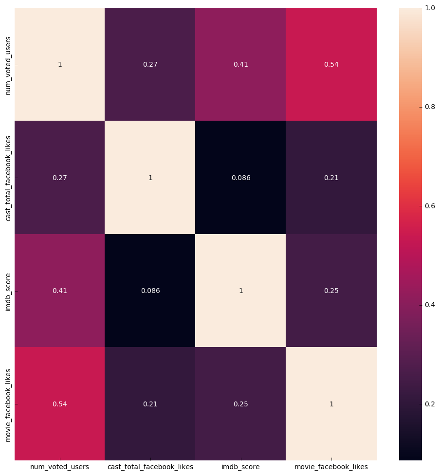

```python
# correlation heatmap
plt.figure(figsize=(12,12))
sns.heatmap(mv2.corr(), annot=True)
```

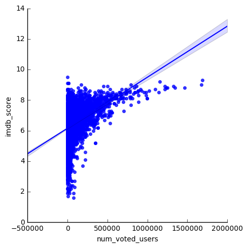

```python
sns.lmplot('num_voted_users', 'imdb_score', mv2)
```

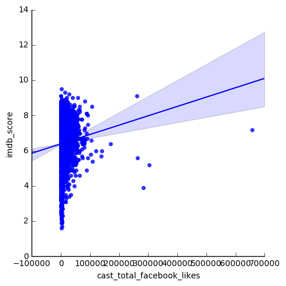

```python
sns.lmplot('cast_total_facebook_likes', 'imdb_score', mv2)
```

Model Development

```python
#assigning columns to X and Y variables
y = mv2['imdb_score']
X = mv2[['num_critic_for_reviews','duration','actor_3_facebook_likes','actor_1_facebook_likes','gross','num_voted_users','cast_total_facebook_likes','num_user_for_reviews','budget','title_year','actor_2_facebook_likes','aspect_ratio']]
```

```python
y.head(2)
```

```
0    7.9
1    7.1
Name: imdb_score, dtype: float64
```

```python
X.head(2)
```

|  | num_critic_for_reviews | duration | actor_3_facebook_likes | actor_1_facebook_likes | gross | num_voted_users | cast_total_facebook_likes | num_user_for_reviews | budget | title_year | actor_2_facebook_likes | aspect_ratio |
| --- | --- | --- | --- | --- | --- | --- | --- | --- | --- | --- | --- | --- |
| 0 | 723 | 178 | 855 | 1000 | 7.60506e+08 | 886204 | 4834 | 3054 | 2.37e+08 | 2009 | 936 | 1.78 |
| 1 | 302 | 169 | 1000 | 40000 | 3.09404e+08 | 471220 | 48350 | 1238 | 3e+08 | 2007 | 5000 | 2.35 |

```python
# build a multiple regression model below

model1 = lm.LinearRegression()
model1.fit(X, y)
model1_y = model1.predict(X)
```

```python
print 'Coefficients: ', model1.coef_
print "y-intercept ", model1.intercept_
```

```
Coefficients:  [ 1.46387110e-03  9.58208103e-03  7.82679775e-05  8.51472906e-05
 -2.24003664e-09  4.03133196e-06 -8.43839623e-05 -4.74673115e-04
 -6.60105320e-11 -9.50132734e-04  8.54430647e-05 -6.89792431e-03]
y-intercept  7.044156840275039
```

```python
pd.DataFrame(zip(X.columns, np.transpose(model1.coef_)))
```

|  | 0 | 1 |
| --- | --- | --- |
| 0 | num_critic_for_reviews | 1.463871e-03 |
| 1 | duration | 9.582081e-03 |
| 2 | actor_3_facebook_likes | 7.826798e-05 |
| 3 | actor_1_facebook_likes | 8.514729e-05 |
| 4 | gross | -2.240037e-09 |
| 5 | num_voted_users | 4.031332e-06 |
| 6 | cast_total_facebook_likes | -8.438396e-05 |
| 7 | num_user_for_reviews | -4.746731e-04 |
| 8 | budget | -6.601053e-11 |
| 9 | title_year | -9.501327e-04 |
| 10 | actor_2_facebook_likes | 8.544306e-05 |
| 11 | aspect_ratio | -6.897924e-03 |

```python
coef = ["%.3f" % i for i in model1.coef_]
xcolumns = [ i for i in X.columns ]
zip(xcolumns, coef)
```

```
[('num_critic_for_reviews', '0.001'),
 ('duration', '0.010'),
 ('actor_3_facebook_likes', '0.000'),
 ('actor_1_facebook_likes', '0.000'),
 ('gross', '-0.000'),
 ('num_voted_users', '0.000'),
 ('cast_total_facebook_likes', '-0.000'),
 ('num_user_for_reviews', '-0.000'),
 ('budget', '-0.000'),
 ('title_year', '-0.001'),
 ('actor_2_facebook_likes', '0.000'),
 ('aspect_ratio', '-0.007')]
```

```python
print "mean square error: ", mean_squared_error(y, model1_y)
print "variance or r-squared: ", explained_variance_score(y, model1_y)
```

```
mean square error:  0.9152595507890339
variance or r-squared:  0.27683749829639903
```

```python
y = mv2['imdb_score']
X = mv2[['aspect_ratio', 'num_voted_users']]
model2 = lm.LinearRegression()
model2.fit(X, y)
model2_y = model2.predict(X)
```

```python
coef = ["%.3f" % i for i in model2.coef_]
xcolumns = [ i for i in X.columns ]
zip(xcolumns, coef)
```

```
[('aspect_ratio', '0.059'), ('num_voted_users', '0.000')]
```

```python
print "y-intercept ", model2.intercept_
```

```
y-intercept  6.042864768519682
```

Model Evaluation

```python
print "mean square error: ", mean_squared_error(y, model2_y)
print "variance or r-squared: ", explained_variance_score(y, model2_y)
```

```
mean square error:  1.0446305014309032
variance or r-squared:  0.17461925841756487
```

```python
# Choose three variables (model3).

y = mv2['imdb_score']
X = mv2[['aspect_ratio', 'num_voted_users', 'num_critic_for_reviews']]

model3 = lm.LinearRegression()
model3.fit(X, y)
model3_y = model3.predict(X)
```

```python
coef = ["%.3f" % i for i in model3.coef_]
xcolumns = [ i for i in X.columns ]
zip(xcolumns, coef)
```

```
[('aspect_ratio', '0.058'),
 ('num_voted_users', '0.000'),
 ('num_critic_for_reviews', '0.001')]
```

```python
print "mean square error: ", mean_squared_error(y, model3_y)
print "variance or r-squared: ", explained_variance_score(y, model3_y)
```

```
mean square error:  1.0412681529583074
variance or r-squared:  0.177275908469395
```

Multiple Regression using Statsmodels

```python
runs_reg_model = ols("imdb_score~num_critic_for_reviews+duration+actor_3_facebook_likes+actor_1_facebook_likes+gross+num_voted_users+cast_total_facebook_likes+num_user_for_reviews+budget+title_year+actor_2_facebook_likes+aspect_ratio",mv2)
runs_reg = runs_reg_model.fit()
print runs_reg.summary()
```

[output not shown]

[output cut: 8935 more lines]

```
aspect_ratio[T.0]                     -0.1028      0.537     -0.191      0.849      -1.168       0.963
num_voted_users                    -1.991e-05   5.98e-05     -0.333      0.740      -0.000    9.88e-05
cast_total_facebook_likes             -0.0002      0.000     -0.472      0.638      -0.001       0.001
==============================================================================
Omnibus:                     2883.787   Durbin-Watson:                   2.000
Prob(Omnibus):                  0.000   Jarque-Bera (JB):       1316569590.432
Skew:                           0.000   Prob(JB):                         0.00
Kurtosis:                    2506.128   Cond. No.                     1.39e+22
==============================================================================

Warnings:
[1] Standard Errors assume that the covariance matrix of the errors is correctly specified.
[2] The input rank is higher than the number of observations.
[3] The smallest eigenvalue is 6.84e-31. This might indicate that there are
strong multicollinearity problems or that the design matrix is singular.
```

```python
runs_reg.mse_resid
```

```
4.747360351299625e-05
```

```python
runs_reg.params
```

```
Intercept                             12.069328
num_critic_for_reviews[T.2.0]         -0.573343
num_critic_for_reviews[T.3.0]         -1.992059
num_critic_for_reviews[T.4.0]         -1.810387
num_critic_for_reviews[T.5.0]         -1.622117
num_critic_for_reviews[T.6.0]         -1.079483
num_critic_for_reviews[T.7.0]         -2.361374
num_critic_for_reviews[T.8.0]         -1.732754
num_critic_for_reviews[T.9.0]         -2.332500
num_critic_for_reviews[T.10.0]        -1.399294
num_critic_for_reviews[T.11.0]        -1.806415
num_critic_for_reviews[T.12.0]        -2.350266
num_critic_for_reviews[T.13.0]        -2.096640
num_critic_for_reviews[T.14.0]        -2.285921
num_critic_for_reviews[T.15.0]        -2.268336
num_critic_for_reviews[T.16.0]        -1.489471
num_critic_for_reviews[T.17.0]        -2.377192
num_critic_for_reviews[T.18.0]        -1.918436
num_critic_for_reviews[T.19.0]        -1.794042
num_critic_for_reviews[T.20.0]        -1.816575
num_critic_for_reviews[T.21.0]        -1.857608
num_critic_for_reviews[T.22.0]        -2.262543
num_critic_for_reviews[T.23.0]        -1.664023
num_critic_for_reviews[T.24.0]        -1.848486
num_critic_for_reviews[T.25.0]        -2.141188
num_critic_for_reviews[T.26.0]        -1.491436
num_critic_for_reviews[T.27.0]        -0.900433
num_critic_for_reviews[T.28.0]        -1.330866
num_critic_for_reviews[T.29.0]        -1.236888
num_critic_for_reviews[T.30.0]        -2.214653
                                        ...
actor_2_facebook_likes[T.23000.0]      6.337043
actor_2_facebook_likes[T.25000.0]      1.165462
actor_2_facebook_likes[T.27000.0]      5.094449
actor_2_facebook_likes[T.29000.0]      3.136500
actor_2_facebook_likes[T.137000.0]    14.141292
actor_2_facebook_likes[T.0]            0.024568
aspect_ratio[T.1.2]                    0.517222
aspect_ratio[T.1.33]                  -0.422331
aspect_ratio[T.1.37]                   0.349132
aspect_ratio[T.1.44]                   0.313919
aspect_ratio[T.1.5]                   -0.091413
aspect_ratio[T.1.66]                   0.343429
aspect_ratio[T.1.75]                   0.451561
aspect_ratio[T.1.77]                   0.196606
aspect_ratio[T.1.78]                   0.243329
aspect_ratio[T.1.85]                  -0.117848
aspect_ratio[T.1.89]                   1.267679
aspect_ratio[T.2.0]                    0.606541
aspect_ratio[T.2.2]                    0.120547
aspect_ratio[T.2.24]                   0.814068
aspect_ratio[T.2.35]                  -0.135024
aspect_ratio[T.2.39]                  -0.644492
aspect_ratio[T.2.4]                    0.267059
aspect_ratio[T.2.55]                   0.388206
aspect_ratio[T.2.76]                   1.657642
aspect_ratio[T.4.0]                    1.560461
aspect_ratio[T.16.0]                   0.699244
aspect_ratio[T.0]                     -0.102759
num_voted_users                       -0.000020
cast_total_facebook_likes             -0.000206
Length: 8964, dtype: float64
```

```python
runs_reg_model2 = ols("imdb_score~aspect_ratio+num_voted_users",mv2)
runs_reg2 = runs_reg_model2.fit()
print runs_reg2.summary()
```

```
                            OLS Regression Results
==============================================================================
Dep. Variable:             imdb_score   R-squared:                       0.205
Model:                            OLS   Adj. R-squared:                  0.202
Method:                 Least Squares   F-statistic:                     56.40
Date:                Tue, 04 Dec 2018   Prob (F-statistic):          7.78e-230
Time:                        17:30:13   Log-Likelihood:                -7170.1
No. Observations:                5043   AIC:                         1.439e+04
Df Residuals:                    5019   BIC:                         1.454e+04
Df Model:                          23
Covariance Type:            nonrobust
========================================================================================
                           coef    std err          t      P>|t|      [0.025      0.975]
----------------------------------------------------------------------------------------
Intercept                6.0282      1.008      5.979      0.000       4.052       8.005
aspect_ratio[T.1.2]      1.7591      1.424      1.236      0.217      -1.032       4.550
aspect_ratio[T.1.33]     0.8822      1.015      0.869      0.385      -1.108       2.872
aspect_ratio[T.1.37]     0.8490      1.013      0.838      0.402      -1.136       2.834
aspect_ratio[T.1.44]     1.4660      1.424      1.030      0.303      -1.325       4.257
aspect_ratio[T.1.5]      0.9591      1.233      0.778      0.437      -1.459       3.377
aspect_ratio[T.1.66]     0.8698      1.015      0.857      0.392      -1.121       2.861
aspect_ratio[T.1.75]     1.7737      1.163      1.525      0.127      -0.506       4.054
aspect_ratio[T.1.77]    -0.1068      1.423     -0.075      0.940      -2.897       2.683
aspect_ratio[T.1.78]     0.0581      1.012      0.057      0.954      -1.927       2.043
aspect_ratio[T.1.85]     0.0963      1.008      0.096      0.924      -1.880       2.072
aspect_ratio[T.1.89]     0.2708      1.424      0.190      0.849      -2.520       3.062
aspect_ratio[T.2.0]      0.5076      1.103      0.460      0.645      -1.655       2.670
aspect_ratio[T.2.2]      1.1038      1.040      1.061      0.289      -0.936       3.144
aspect_ratio[T.2.24]     0.1484      1.422      0.104      0.917      -2.639       2.936
aspect_ratio[T.2.35]     0.0834      1.008      0.083      0.934      -1.892       2.059
aspect_ratio[T.2.39]     0.2884      1.040      0.277      0.782      -1.751       2.328
aspect_ratio[T.2.4]      0.6479      1.162      0.557      0.577      -1.631       2.926
aspect_ratio[T.2.55]     0.4902      1.234      0.397      0.691      -1.928       2.908
aspect_ratio[T.2.76]     0.9912      1.163      0.853      0.394      -1.288       3.270
aspect_ratio[T.4.0]      1.5922      1.077      1.478      0.139      -0.520       3.704
aspect_ratio[T.16.0]     1.0619      1.019      1.042      0.297      -0.936       3.060
aspect_ratio[T.0]       -0.0703      1.010     -0.070      0.944      -2.050       1.909
num_voted_users       3.376e-06   1.05e-07     32.167      0.000    3.17e-06    3.58e-06
==============================================================================
Omnibus:                      612.628   Durbin-Watson:                   1.915
Prob(Omnibus):                  0.000   Jarque-Bera (JB):             1016.569
Skew:                          -0.836   Prob(JB):                    1.80e-221
Kurtosis:                       4.429   Cond. No.                     5.56e+07
==============================================================================

Warnings:
[1] Standard Errors assume that the covariance matrix of the errors is correctly specified.
[2] The condition number is large, 5.56e+07. This might indicate that there are
strong multicollinearity or other numerical problems.
```

```python
runs_reg2.mse_resid
```

```
1.0105277225751286
```